# Note

Zehui Bai

2025-06-11 20:55:17

# rix

The phrase **“A new approach to Shiny development & deployment with Nix and `{rix}`”** refers to using **Nix** (a functional package manager) and the **{rix} R package** to manage, develop, and deploy Shiny applications in a **reproducible, isolated, and declarative environment**.

https://rpodcast.github.io/rixshiny-rmed2025/#/title-slide

## 🌟 1. Why a New Approach Is Needed for Shiny Development & Deployment

Shiny is great for creating web applications with R. However, **Shiny app development and deployment** can face challenges:

- ❌ Dependency hell: Installing exact versions of R packages can be a nightmare.
- ❌ Environment mismatch: Code that runs on your machine might break on the server.
- ❌ Deployment complexity: Reproducing the dev environment on a server is often non-trivial.

## 🛠 2. What Is **Nix**?

**Nix** is a **purely functional package manager** that provides:

- **Reproducibility**: All dependencies are defined and locked, ensuring identical environments.
- **Isolation**: It builds environments in isolation, avoiding pollution from your system.
- **Declarative builds**: You write a configuration file (`default.nix`, `shell.nix`, etc.) that describes exactly what you need.

For R/Shiny, this means:

- You can define your full R environment, including the R version, packages, system dependencies (e.g., `libxml2`, `curl`), and tools (e.g., `pandoc`, `shiny-server`) in one place.
- You can recreate that exact environment anywhere (dev, test, prod).

## 📦 3. What Is `{rix}`?

`{rix}` is a modern **R package** developed to bridge R development with Nix infrastructure. It aims to simplify:

- **Writing and managing Nix expressions** for R environments.
- **Creating reproducible environments** for R and Shiny apps.
- **Exporting R project metadata** to Nix (like `renv.lock`, `DESCRIPTION`, etc.)

Key features include:

| Feature | Description |
| --- | --- |
| `rix::init()` | Initializes a Nix environment for your R project |
| `rix::build()` | Builds a fully reproducible R environment using Nix |
| `rix::run()` | Launches the app inside a Nix shell |
| `rix::deploy()` | Deploys the Shiny app to a target server, also using Nix |

## 🚀 4. Shiny Deployment Workflow with Nix + `{rix}`

### 🔧 Step 1: Set Up Your Project

Your Shiny project directory should include:

- `app.R` or `ui.R`/`server.R`
- `DESCRIPTION` (optional, or inferred)
- R package dependencies
- Optional: `renv.lock` or `packrat.lock`

### 📦 Step 2: Use `{rix}` to Generate Nix Configs

```r
rix::init()
```

- Creates `default.nix`, `shell.nix` files.
- Defines the R version, packages, and system libraries.

### 🧪 Step 3: Run the App in a Nix Shell

```bash
nix develop
Rscript app.R
```

Or from R:

```r
rix::run()
```

This ensures the app runs inside the isolated environment defined by Nix.

### 📤 Step 4: Deploy the App (Optional)

```r
rix::deploy(target = "nix-server")
```

- Deploys your app to a Nix-compatible server.
- Ensures the exact same versions and setup as in development.

## 🧠 5. Benefits of Using Nix + `{rix}` for Shiny

| Benefit | Description |
| --- | --- |
| 🔁 Reproducibility | Same environment across machines, CI, and servers |
| 🧼 Isolation | Prevents conflicts between projects or system libraries |
| 🔄 Version control | Fully versioned environment with rollback ability |
| 📦 Full-stack | Handles system libraries, R versions, and package dependencies |
| 🖥️ Infrastructure agnostic | Can run on macOS, Linux, Docker, servers |

## 📚 6. Comparison With Other Tools

| Tool | Dependency Isolation | System-Level Control | Server Reproducibility |
| --- | --- | --- | --- |
| `renv` | ✅ (R packages) | ❌ | ⚠️ (manual for server setup) |
| Docker | ✅ | ✅ | ✅ |
| Nix + `{rix}` | ✅ | ✅ | ✅✅✅ |

## 📎 7. Example: Minimal Nix Expression via `{rix}`

```
{ pkgs ? import <nixpkgs> {} }:

pkgs.mkShell {
  buildInputs = [
    pkgs.rWrapper.override {
      packages = with pkgs.rPackages; [
        shiny
        dplyr
        ggplot2
      ];
    }
  ];
}
```

This file lets you launch a shell where R has all needed packages and libraries available.

## 📌 Final Thoughts

Using **Nix + `{rix}`** offers a powerful, reproducible, and modern approach to **Shiny app development and deployment**, especially for teams that:

- Value reproducibility (e.g., pharma, data science teams),
- Work across environments (local dev, CI/CD, production),
- Need to avoid “it works on my machine” scenarios.

# R package development with GitHub Pages and pkgdown

https://rconsortium.github.io/RMedicine_website/files/R%20package%20development%20with%20GitHub%20Pages%20and%20pkgdown.pdf

https://ggnot2.site/slides.html https://ggnot2.site/ https://github.com/melissavanbussel/rmedicine/tree/main

R package development with GitHub Pages and pkgdown https://ggnot2.site/slides.html#/title-slide

# Survival analysis with tidymodels

https://github.com/hfrick/tidymodels-survival-workshop

https://hfrick.github.io/tidymodels-survival-workshop/

**The initial split**

```
## [1] 1805
```

```
## [1] 452
```

**Exploratory data analysis**

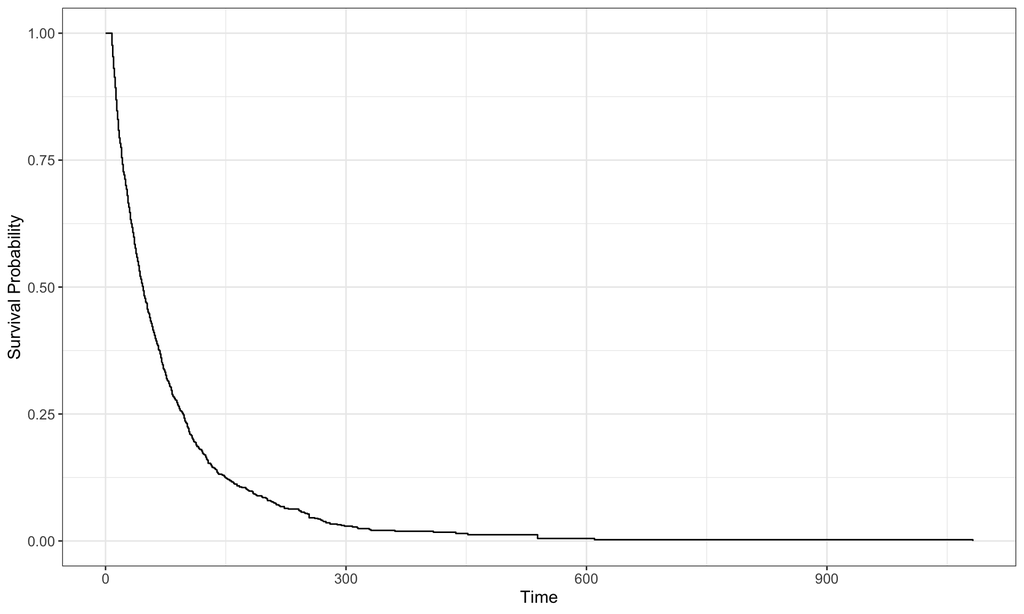

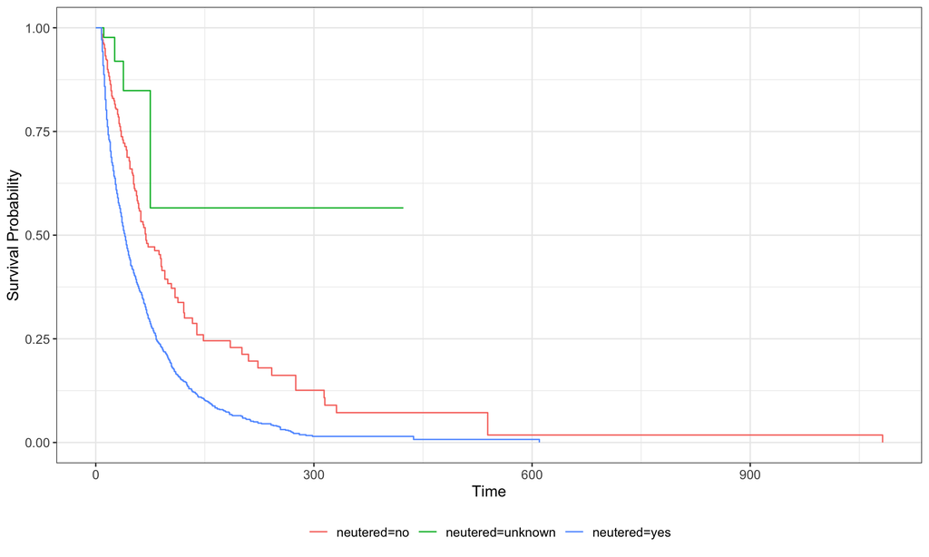

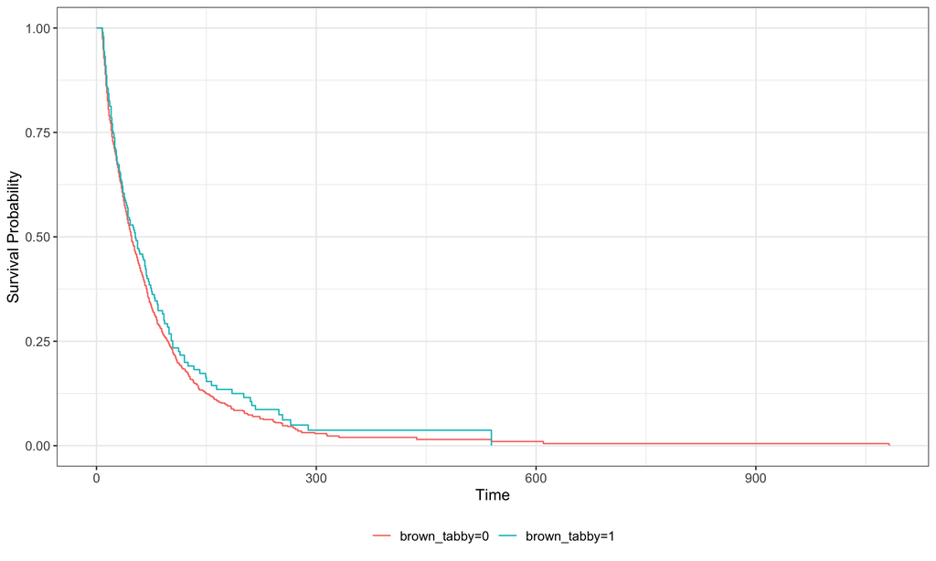

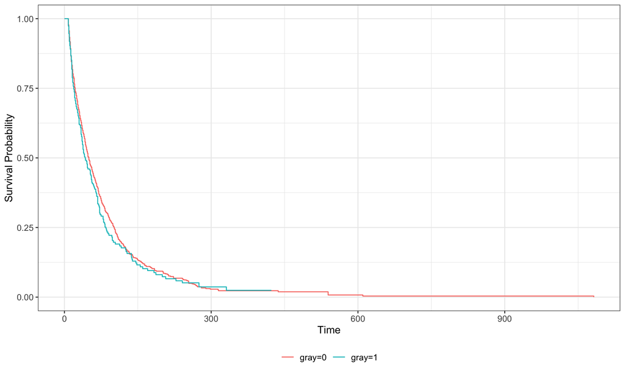

**To specify a model**

```
## Proportional Hazards Model Specification (censored regression)
##
## Computational engine: glmnet
```

```
## Decision Tree Model Specification (censored regression)
##
## Computational engine: rpart
```

## Proportional hazards (PH) model

1. **Model Formula**

$$\lambda(t \mid x_i) = \lambda_0(t) \cdot \exp(x_i^T \beta)$$

- **λ(t | xᵢ)**: The hazard (instantaneous risk of event — here, adoption) at time *t* for subject *i*.
- **λ₀(t)**: The **baseline hazard function** — this is shared across all individuals and describes the hazard when all covariates are zero.
- **xᵢᵀβ**: The linear combination of covariates (intake conditions, etc.) and their coefficients.
- **exp(xᵢᵀβ)**: A positive scaling factor adjusting the baseline hazard depending on the individual’s characteristics.

So the total hazard is just the baseline hazard scaled by a person-specific factor.

2. **Proportionality Concept**
- Hazards for individuals are **proportional** over time — the ratio of hazards between any two individuals is constant over time.
- As a result, **survival curves don’t cross**, and differences in risk are consistent regardless of the specific time point.

## Decision tree

```
## parsnip model object
##
## $rpart
## n= 1765
##
## node), split, n, deviance, yval
##       * denotes terminal node
##
## 1) root 1765 1981.0090 1.0000000
##   2) neutered=no,unknown 696  576.4117 0.5937228 *
##   3) neutered=yes 1069 1318.2450 1.1714650
##     6) intake_condition=ill_mild,ill_moderatete,normal,under_age_or_weight,other 921 1063.5830 1.0808970 *
##     7) intake_condition=feral,fractious 148  195.7649 2.3866130 *
##
## $survfit
##
## Call: prodlim::prodlim(formula = form, data = data)
```

```
##
## Right-censored response of a survival model
##
## No.Observations: 1765
##
## Pattern:
##                 Freq
##  event          1116
##  right.censored 649
##
## $levels
## [1] "0.593722848021763" "1.08089686322063"  "2.38661313111009"
##
## attr(,"class")
## [1] "pecRpart"
```

```
## ══ Workflow [trained] ══════════════════════════════════════════════════════════
## Preprocessor: Formula
## Model: decision_tree()
##
## ── Preprocessor ────────────────────────────────────────────────────────────────
## event_time ~ .
##
## ── Model ───────────────────────────────────────────────────────────────────────
```

```
## $rpart
## n= 1765
##
## node), split, n, deviance, yval
##       * denotes terminal node
##
## 1) root 1765 1981.0090 1.0000000
##   2) neutered=no,unknown 696  576.4117 0.5937228 *
##   3) neutered=yes 1069 1318.2450 1.1714650
##     6) intake_condition=ill_mild,ill_moderatete,normal,under_age_or_weight,other 921 1063.5830 1.0808970 *
##     7) intake_condition=feral,fractious 148  195.7649 2.3866130 *
##
## $survfit
##
## Call: prodlim::prodlim(formula = form, data = data)
```

```
##
## Right-censored response of a survival model
##
## No.Observations: 1765
##
## Pattern:
##                 Freq
##  event          1116
##  right.censored 649
##
## $levels
## [1] "0.593722848021762" "1.08089686322063"  "2.38661313111009"
##
## attr(,"class")
## [1] "pecRpart"
```

| .pred_time |
| --- |
| 1.0808969 |
| 0.5937228 |
| 0.5937228 |
| 1.0808969 |
| 2.3866131 |
| 0.5937228 |
| 1.0808969 |
| 0.5937228 |
| 1.0808969 |
| 0.5937228 |

[output cut: 40 more lines]

| .pred |
| --- |

[output cut: 40 more lines]

| .eval_time | .pred_survival |
| --- | --- |
| 0 | 1.00000000 |
| 5 | 1.00000000 |
| 10 | 0.92254305 |
| 15 | 0.81255067 |
| 20 | 0.74920482 |
| 25 | 0.68955845 |
| 30 | 0.63736197 |
| 35 | 0.58800847 |
| 40 | 0.53624885 |
| 45 | 0.49455846 |

[output cut: 64 more lines]

| .pred | .pred_time | event_time | sex | neutered | intake_condition | intake_type | latitude | longitude | black | brown | brown_tabby | calico | cream | gray | gray_tabby | orange | orange_tabby | tan | tortie | white |
| --- | --- | --- | --- | --- | --- | --- | --- | --- | --- | --- | --- | --- | --- | --- | --- | --- | --- | --- | --- | --- |
|  | 1.0808969 | 36 | male | yes | normal | stray | 33.83131 | -118.0868 | 0 | 0 | 1 | 0 | 0 | 0 | 0 | 0 | 0 | 0 | 0 | 1 |
|  | 0.5937228 | 16+ | male | no | ill_mild | stray | 33.84373 | -118.1948 | 0 | 0 | 0 | 0 | 0 | 0 | 0 | 0 | 0 | 0 | 0 | 1 |
|  | 0.5937228 | 12+ | male | no | normal | stray | 33.79350 | -118.1829 | 1 | 0 | 0 | 0 | 0 | 0 | 0 | 0 | 0 | 0 | 0 | 1 |
|  | 1.0808969 | 16 | female | yes | normal | stray | 33.84645 | -118.1916 | 1 | 0 | 0 | 0 | 0 | 0 | 0 | 0 | 0 | 0 | 0 | 1 |
|  | 2.3866131 | 22 | male | yes | fractious | stray | 33.86064 | -118.1883 | 0 | 0 | 1 | 0 | 0 | 0 | 0 | 0 | 0 | 0 | 0 | 1 |
|  | 0.5937228 | 16 | female | no | normal | stray | 33.78622 | -118.1633 | 0 | 0 | 0 | 0 | 0 | 1 | 0 | 0 | 0 | 0 | 0 | 1 |
|  | 1.0808969 | 294 | female | yes | normal | stray | 33.79168 | -118.1995 | 0 | 0 | 0 | 0 | 0 | 1 | 0 | 0 | 0 | 0 | 0 | 1 |
|  | 0.5937228 | 68+ | male | no | normal | stray | 33.78555 | -118.1840 | 0 | 0 | 0 | 0 | 0 | 0 | 0 | 0 | 1 | 0 | 0 | 1 |
|  | 1.0808969 | 31 | female | yes | normal | stray | 33.80409 | -118.1869 | 1 | 0 | 0 | 0 | 0 | 0 | 0 | 0 | 0 | 0 | 0 | 1 |
|  | 0.5937228 | 24+ | male | no | normal | stray | 33.79730 | -118.2000 | 0 | 0 | 0 | 0 | 0 | 0 | 0 | 0 | 0 | 0 | 0 | 1 |

[output cut: 40 more lines]

## Evaluating models

For our demo data set of n = 50 cats, we’ll make predictions every 30 days for roughly the first 10 months:

| .pred | .pred_time | event_time |
| --- | --- | --- |
|  | 1.0808969 | 36 |
|  | 0.5937228 | 16+ |
|  | 0.5937228 | 12+ |
|  | 1.0808969 | 16 |
|  | 2.3866131 | 22 |
|  | 0.5937228 | 16 |
|  | 1.0808969 | 294 |
|  | 0.5937228 | 68+ |
|  | 1.0808969 | 31 |
|  | 0.5937228 | 24+ |

[output cut: 40 more lines]

**Concordance**

The concordance statistic (“c-index”, Harrell et al (1996)) is a metric that quantifies that the rank order of the times is consistent with the model score.

| .metric | .estimator | .estimate |
| --- | --- | --- |
| concordance_survival | standard | 0.311943 |

# Quarto

**Materials**

Slides for this intro: mine.quarto.pub/quarto-dashboards-rmed

Source code for slides: github.com/mine-cetinkaya-rundel/quarto-dashboards-rmed/blob/main/index.qmd

# teal

- Create Posit Cloud account: https://posit.cloud/
- Open the repo: https://github.com/pharmaverse/tealworkshop-rmedicine2025